# Fakultät für Physik

## Physikalisches Praktikum P2 für Studierende der Physik

Versuch **H13** (Stand: **April 2026**)

[Raum F1-15](https://labs.physik.kit.edu/img/Klassische-Praktika/Lageplan_P2.png)

# [Vakuum](https://gitlab.kit.edu/kit/etp-lehre/p2-praktikum/students/-/blob/main/Vakuum/README.md)

Name: **Haag** Vorname: **Finn** E-Mail: **uvvln@student.kit.edu**

\begin{equation*} \begin{split} &\\ &\\ \end{split} \end{equation*}

Name: **Trunzer** Vorname: **Kiran** E-Mail: **urmat@student.kit.edu**

\begin{equation*} \begin{split} &\\ &\\ &\\ \end{split} \end{equation*}

Gruppennummer: **Di7,Di16**

\begin{equation*} \begin{split} &\\ &\\ &\\ \end{split} \end{equation*}

Betreuer: **Jonathan Kley**

\begin{equation*} \begin{split} &\\ &\\ &\\ \end{split} \end{equation*}

Versuch durchgeführt am: __________________

**Beanstandungen zu Protokoll Version _____:**

\begin{equation*} \begin{split} &\\ &\\ &\\ &\\ &\\ &\\ &\\ &\\ &\\ &\\ \end{split} %\text{\vspace{10cm}} \end{equation*}

Testiert am: __________________ Testat: __________________

# Durchführung

ℹ️ **Detaillierte Kommentare zur Durchführung der Aufgaben finden Sie in der Datei Vakuum_Hinweise.ipynb**

## Aufgabe 1: Versuchsaufbau

### Aufgabe 1.1: Orientierung und Beschreibung des Versuchsaufbaus

- Verschaffen Sie sich einen Überblick über die verwendeten Apparaturen und beschreiben Sie sie in eigenen Worten.

**V E R S U C H S B E S C H R E I B U N G**

Die vier Hauptkomponenten des Versuchsaufbaus waren der Rezipient $RZ$, eine Turbomolekularpumpe $TMP$, eine Drehschieberpumpe $DSP$ und ein Referenzvolumen $RV$ - unten mehr zu den einzelnen Komponenten.

Verbunden waren diese Hauptkomponenten über drei Ventile:

- $V_1$ zwischen $DSP$ und $TMP$
- $V_2$ zwischen $TMP$ und $RZ/RV$
- $V_3$ zwischen $RV$ und $RZ$

Zusätzlich waren zwei Ventiele $B_1$ und $B_2$, im Aufbau verbraut, um die Apperatur im notfall zu belüften. Zwischen der $TMP$ und der $V_1$ war zudem ein austauschbares Leitungselement, welches in Aufgabe 2.2 zum Einsatz kommt. Zur Messung des Druckes standen zwei Arten von Messinstrumenten zu Verfügung. Einerseits Wärmeleitvakuummeter $ T_1 , T_2$ und $T_3$ welches, mittels der druckabhänigen Wärmeleitfähigkeit des Restgases, zum Messen der höheren Drücke ab $5\times 10^{-4} mbar$ verrwendet wird. Andererseits das Ionisationsvakuummeter das bei Drücken bis zu $10^{-9} mbar$ verwendung kommt und durch Messung des Ionenstrom, des Ioniseriten Restgases zu seinen Werten kommt.

Die Unsicherheiten der Wärmeleitvakuummeter liegen bei:

| Druck $p$ in $mbar$ | relative Ungenauigkeit |
| --- | --- |
| $(5\cdot10^{-4}, 10^{-3})$ | $\pm10\%$ |
| $(10^{-3},10^2)$ | $\pm2\%$ |
| $(10^2,10^3)$ | $\pm25\%$ |

und für das Ionisationsvakuummeter bei $\pm30\%$.

```python
import matplotlib.pyplot as plt
import matplotlib.image as mpimg
import numpy as np
import kafe2
import pandas as pd
```

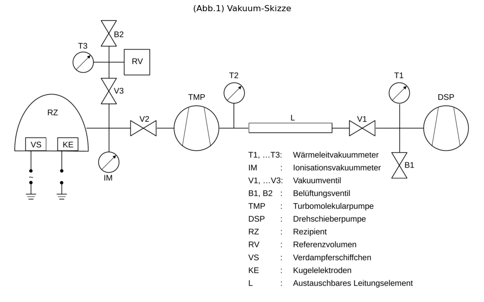

```python
# Bild laden und anzeigen
img = mpimg.imread("VakuumSkizze.png")

fig = plt.figure("Vakuum-Skizze", figsize=(12, 8))
imgplot = plt.imshow(img)
plt.axis('off')                    # Achsen komplett ausblenden
plt.title("(Abb.1) Vakuum-Skizze")
plt.show()
```

### Aufgabe 1.2: Gasentladung (Demonstrationsversuch)

- Schalten Sie das Hochspannungsgerät zur Erzeugung der Gasentladungen ein.
- Evakuieren Sie den Rezipienten (RZ) und die Gasentladungsröhre mit Hilfe der Drehschieberpumpe (DSP).
- Senken Sie den Druck kontinuierlich, bis die Gasentladung erlischt.
- Beschreiben Sie die Gasentladung in Abhängigkeit vom Gasdruck.

**V E R S U C H S B E S C H R E I B U N G**

Dieser Versuch wurde am Versuchsaufbau 153 durchgeführt. Da dort am RZ noch eine Gasentladungsröhre eingebaut war. Für diesen Versuch wurden die Ventile V1 und V2 geöffnet und somit die DSP mit dem RZ verbunden. Zum Evakuieren wurde hier ausschließlich die DSP verwendet, weshalb die Gasentladung nur in einem tendenziell gröberem Vakuum untersucht wurde. Die Gasentladungsröhre wurde, zuerst noch bei Normaldruck, unter Spannung gesetzt. Innerhalb der Röhre wurden damit Elektronen beschleunigt, welche mit der in der Röhre befindenden Luft, größtenteils Stickstoff, stießen. Haben die Elektronen genug Energie, also haben sie eine gewissen Strecke im Beschleunigungsfeld zurückgelegt, so können die Stickstoffatome kurzzeitig angeregt werden, woraufhin sie sich wieder abregen und ein Photon mit einer charakteristischen Wellenlänge emittieren. Nun werden die Elektronen weiter beschleunigt, bis sich der Vorgang in äquidistanten Abständen wiederholt. Dies geschieht bei Normaldruck allerdings nur kaum bis gar nicht, da die Elektronen zu oft durch Stöße an Energie verlieren, bevor sie zu einer Anregung genug Energie haben. Wird der Druck allerdings gesenkt, so findet zuerst immer mehr Gasentladung statt, da nun weniger Stoßpartner vorhanden sind, die die Elektronen vorzeitig entschleunigen. Somit wird das beobachtbare Licht erst immer heller. In extremen Tiefdruckbereichen lässt die beobachtbare Intensität jedoch irgendwann nach, da mit der fortlaufenden Evakuierung die Wahrscheinlichkeit sinkt, mit der die Elektronen überhaupt einen Stoßpartner treffen

[figure not shown]

```python
img = mpimg.imread("1_2.jpg")

fig = plt.figure("Gasentladung", figsize=(12, 8))
imgplot = plt.imshow(img)
plt.axis('off')
plt.title("(Abb.2) Gasentladung Stickstoff")
plt.show()
```

## Aufgabe 2: Saugvermögen und Strömungsleitwert

### Aufgabe 2.1: Saugvermögen der DSP

Evakuieren Sie die Apparatur mit Hilfe der DSP und stellen Sie die folgenden Größen, bestimmt aus dem **Druck bei T1**, geeignet graphisch dar:

- Das effektive Saugvermögen als Funktion des Drucks $S_{\mathrm{eff}}(p)$.
- Den Druck als Funktion der Zeit $p(t)$, für eine geeignete Auswahl an Messpunkten.

**V E R S U C H S B E S C H R E I B U N G**

In diesem Versuch sollten wir das Saugvermögen der Drehschieberpumpe (DSP) messen. Hierfür wurde die Apparatur vollständig belüftet. Anschließend wird der Druck mithilfe der Drehschieberpumpe verringert und mit der Messstation T1 für einen Zeitraum von 5 Minuten alle 5 Sekunden ein Wert gemessen. Mithilfe dieser Messwerte wird nun das Saugvermögen S(p) berechnet, das Volumen konnten wir aus dem Datenblatt entnehmen, für n wählten wir den Wert $1$.

$$ S(p) = \frac{V_{RZ}}{n(t_i + 1 - t_i)} ln(\frac{p_i}{pi+ 1}) $$

**L Ö S U N G**

[output not shown]

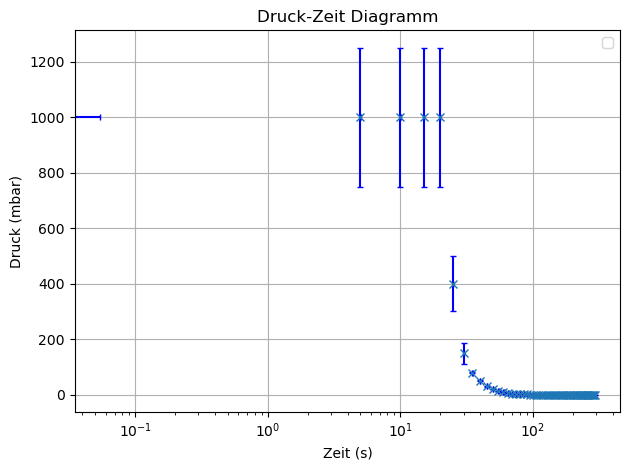

```python
p_21 = np.array([1000, 1000, 1000, 1000, 1000, 400, 150, 80, 51, 30, 20, 13.5, 9.13, 6.25, 4.27, 2.91, 2.04, 1.5, 1.14, 0.72, 0.69, 0.48, 0.37, 0.30, 0.25, 0.21, 0.185, 0.164, 0.149, 0.134, 0.125, 0.114, 0.106, 0.1, 0.0942, 0.0903, 0.0871, 0.0832, 0.08, 0.078, 0.076, 0.075, 0.073, 0.071, 0.069, 0.067, 0.065, 0.064, 0.063, 0.062, 0.061, 0.060, 0.059, 0.058, 0.057, 0.056, 0.055, 0.055, 0.054, 0.053])

t=np.arange(0, len(p_21) * 5, 5)

#Unsicherheiten
delta_p = np.zeros_like(p_21)
for i, p in enumerate(p_21):
    if 5e-4 <= p < 1e-3:
        delta_p[i] = 0.10 * p
    elif 1e-3 <= p < 1e2:
        delta_p[i] = 0.02 * p
    elif 1e2 <= p <= 1e3:
        delta_p[i] = 0.25 * p
    else:
        delta_p[i] = 0.02 * p


plt.xscale('log')
plt.errorbar(t, p_21, yerr=delta_p, xerr=0.0539, fmt='x', ecolor='blue', capsize=2)
plt.xlabel('Zeit (s)')
plt.ylabel('Druck (mbar)')
plt.title('Druck-Zeit Diagramm')
plt.grid(True)
plt.legend()
plt.tight_layout()
plt.show()
```

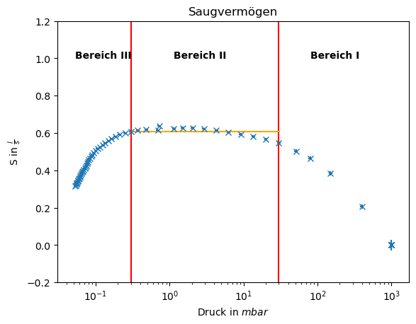

```python
V = 10.119

def S_p(t,p,p_0,V,t_0 = 0):
    return V/(t_0-t)*np.log(p/p_0)

def S_err(t,p,p_0,V,t_0=0):
    return V*np.sqrt(((0.0539)/(t-t_0))**2+((0.196*np.log(p/p_0))/(t-t_0)**2)**2)

def mean(list,start, finish):
    sum = 0
    i = 0
    for _ in range(start,finish+1):
        sum += list[_]
        i += 1
    return sum/i

S = [S_p(t[i]+20,p_21[i],p_0=p_21[0],V=V) for i in range(len(p_21))]
Serr= [S_err(t[i]+20,p_21[i],p_0=p_21[0],V=V) for i in range(len(p_21))]

plt.errorbar(x=p_21,y=S,xerr=0.0539*p_21,yerr=Serr, fmt='x', ls='none')
plt.title('Saugvermögen')
plt.xlabel('Druck in $mbar$')
plt.ylabel(r'S in $\frac{{l}}{{s}}$')
plt.xscale('log')
plt.ylim(-0.2,1.2)
plt.axvline(x=p_21[9],color="red")
plt.axvline(x=p_21[23],color="red")
plt.axhline(y=mean(list=S,start=9,finish=23),xmin=0.21,xmax=0.63,color='orange')
plt.text(x=p_21[7],y=1,s='Bereich I',fontweight='bold',fontsize='medium')
plt.text(x=p_21[18],y=1,s='Bereich II',fontweight='bold',fontsize='medium')
plt.text(x=p_21[59],y=1,s='Bereich III',fontweight='bold',fontsize='medium')

plt.show()
```

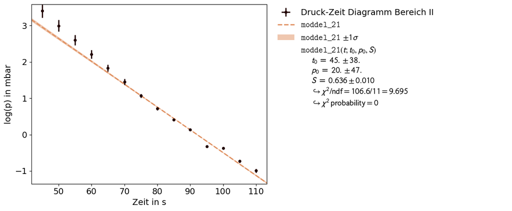

```python
def moddel_21(t,t_0=t[9],p_0=p_21[9],S=mean(list=S,start=9,finish=23)):
    return np.log(p_0*np.exp(-(S)/(V)*(t-t_0)))

dataset = kafe2.XYContainer(x_data=t[9:23],y_data=np.log(p_21[9:23]))
dataset.axis_labels=['Zeit in s', 'log(p) in mbar']
dataset.label='Druck-Zeit Diagramm Bereich II'
dataset.add_error(axis='x',err_val=0.196)
dataset.add_error(axis='y',err_val=0.0539,relative=True)

fit = kafe2.Fit(dataset,model_function=moddel_21)
fit.limit_parameter("t_0", lower=0)

fit.do_fit()
fit_result=kafe2.Plot([fit])

fit_result.plot()
plt.show()
```

**D I S K U S S I O N**

Schaut man sich nun den zweiten Graphen an so erkennt man das sich dieser in drei Bereiche einteilen lässt. Im ersten Bereich steigt das Saugvermögen an da anfangs die Gasdichte sehr hoch ist und die Pumpe ineffizent arbeitet. Im zweiten Bereich ist das Saugvermögen Konstant hier arbeitet die Pumpe am effektifsten. Im dritten Bereich kommt die DSP an ihre grenzen und die Gasdichte wird sehr gering und sorgt somit dafür das nur noch wenige Teilen in die Pumpe kommen. Schaut man sich nun den zweiten Bereich von Sekunde $45$ bis $110$ genauer an und führt diesen Fit durch $p(t)=p_0 ⋅ e^{-\frac {S}V(t−t_0)}$, so sieht man das vorallem am Anfang des zweiten Bereichs eine große Abweichung herscht. Dies liegt daran das der Fit vereinfacht ist und nicht alle Realen Prozesse abbildet. Zudem Können Ablesefeheler zu starken Abweichungen führen.

### Aufgabe 2.2: Leitwert eines dünnen zylindrischen Rohrs

- Bereiten Sie die Apparatur darauf vor Druckmessungen vor und hinter einem am Experiment ausliegenden Metallrohr vorzunehmen.
- Bestimmen Sie die Drucke $p_{1}$ (**bei T1**) vor und $p_{2}$ (**bei T2**) hinter dem Rohr als Funktion der Zeit.
- Bestimmen Sie aus den gewonnenen Daten den Leitwert $L$ des Rohrs.

**V E R S U C H S B E S C H R E I B U N G**

**L Ö S U N G**

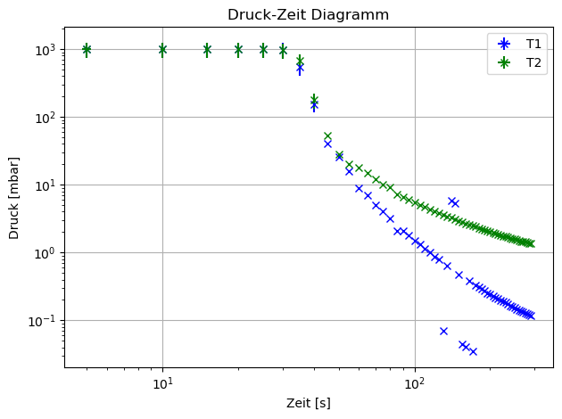

```python
p_T1 = np.array([1000, 1000, 1000, 1000, 1000, 1000, 980, 540, 154, 40, 26, 16, 9, 7, 5, 4, 3.2, 2.1, 2.08, 1.77, 1.51, 1.31, 1.13, 0.996, 0.879, 0.787, 0.0701, 0.634, 5.76, 5.25, 0.478, 0.0443, 0.0410, 0.378, 0.0349, 0.327, 0.309, 0.288, 0.272, 0.253, 0.242, 0.229, 0.216, 0.207, 0.198, 0.191, 0.184, 0.173, 0.165, 0.158, 0.153, 0.147, 0.141, 0.136, 0.132, 0.128, 0.124, 0.121, 0.118])
p_T2 = np.array([1000, 1000, 1000, 1000, 1000, 1000, 960, 670, 176, 53, 28, 20, 18, 15, 12, 10, 9.2 , 7.28, 6.64, 6.00, 5.50, 5.00, 4.68, 4.35, 4.08, 3.82, 3.61, 3.41, 3.24, 3.06, 2.94, 2.80, 2.69, 2.57, 2.47, 2.39, 2.30, 2.22, 2.15, 2.08, 2.02, 1.96,1.90, 1.86, 1.81, 1.76, 1.72, 1.69, 1.64, 1.61, 1.57, 1.53, 1.51, 1.47, 1.45, 1.43, 1.40, 1.37, 1.35])
#, 0.115
t=np.arange(0, len(p_T1) * 5, 5)

delta_T1 = np.zeros_like(p_T1)
for i, p in enumerate(p_T1):
    if 5e-4 <= p < 1e-3:
        delta_T1[i] = 0.10 * p
    elif 1e-3 <= p < 1e2:
        delta_T1[i] = 0.02 * p
    elif 1e2 <= p <= 1e3:
        delta_T1[i] = 0.25 * p
    else:
        delta_T1[i] = 0.02 * p

delta_T2 = np.zeros_like(p_T2)
for i, p in enumerate(p_T2):
    if 5e-4 <= p < 1e-3:
        delta_T2[i] = 0.10 * p
    elif 1e-3 <= p < 1e2:
        delta_T2[i] = 0.02 * p
    elif 1e2 <= p <= 1e3:
        delta_T2[i] = 0.25 * p
    else:
        delta_T2[i] = 0.02 * p



plt.xscale('log')
plt.errorbar(t ,p_T1 ,yerr=delta_T1,xerr=0.196,fmt='x',ls='none',color='blue',label='T1')
plt.errorbar(t ,p_T2,yerr=delta_T2,xerr=0.196,fmt='x',ls='none',color='green',label='T2')
plt.xlabel("Zeit [s]")
plt.ylabel("Druck [mbar]")
plt.yscale('log')
plt.title("Druck-Zeit Diagramm")
plt.legend()
plt.grid(True)
plt.tight_layout()
plt.show()
```

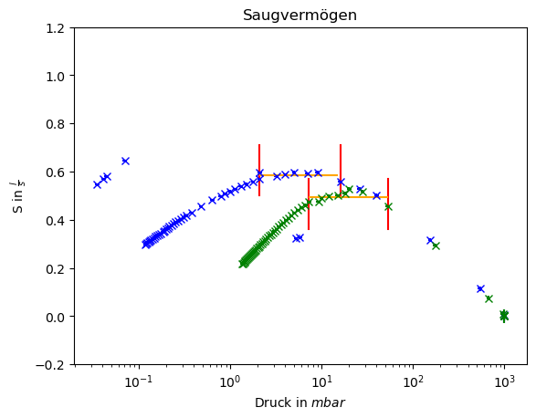

```python
V2= 9.9054

S1 = [S_p(t[i]+20,p_T1[i],p_T1[0],V=V) for i in range(len(p_T1))]
Serr1= [S_err(t[i]+20,p_T1[i],p_0=p_T1[0],V=V) for i in range(len(p_T1))]

S2 = [S_p(t[i]+20,p_T2[i],p_0=p_T2[0],V=V) for i in range(len(p_T2))]
Serr2= [S_err(t[i]+20,p_T2[i],p_T2[0],V=V) for i in range(len(p_T2))]

plt.errorbar(x=p_T1,y=S1,xerr=0.0539*p_T1,yerr=Serr1,fmt='x', ls='none', color='blue')
plt.errorbar(x=p_T2,y=S2,xerr=0.0539*p_T2,yerr=Serr2, fmt='x', ls='none', color='green')
plt.title('Saugvermögen')
plt.xlabel('Druck in $mbar$')
plt.ylabel(r'S in $\frac{{l}}{{s}}$')
plt.xscale('log')
plt.ylim(-0.2,1.2)

plt.axvline(x=p_T1[11],ymin= 0.5 ,ymax= 0.65,color="red")
plt.axvline(x=p_T1[17],ymin= 0.5 ,ymax= 0.65,color="red")
plt.axhline(y=mean(list=S1,start=11,finish=17),xmin=0.41,xmax=0.58,color='orange')

plt.axvline(x=p_T2[9],ymin= 0.4 ,ymax= 0.55,color="red")
plt.axvline(x=p_T2[17],ymin= 0.4 ,ymax= 0.55,color="red")
plt.axhline(y=mean(list=S2,start=9,finish=17),xmin=0.52,xmax=0.69,color='orange')
plt.show()
```

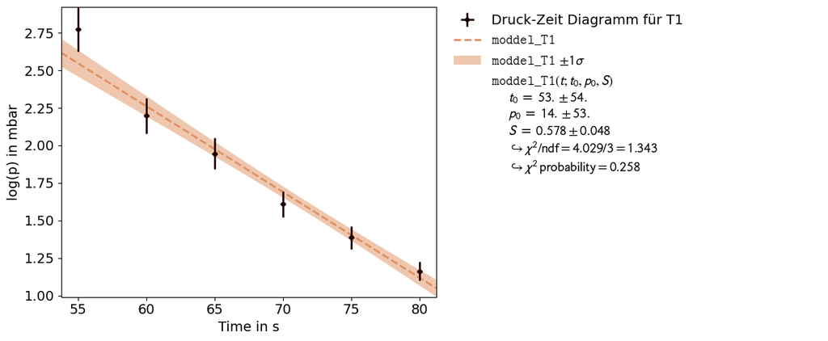

[figure not shown]

```python
def moddel_T1(t,t_0=t[11],p_0=p_T1[11],S=mean(list=S1,start=11,finish=17)):
    return np.log(p_0*np.exp(-(S)/(V)*(t-t_0)))

# Create Dataset
dataset_S1 = kafe2.XYContainer(x_data=t[11:17],y_data=np.log(p_T1[11:17]))
dataset_S1.axis_labels=['Time in s', 'log(p) in mbar']
dataset_S1.label='Druck-Zeit Diagramm für T1'

dataset_S1.add_error(axis='x',err_val=0.196)
dataset_S1.add_error(axis='y',err_val=0.0539,relative=True)

fit_S1 = kafe2.Fit(dataset_S1,model_function=moddel_T1)
fit_S1.limit_parameter("t_0", lower=0)
fit_S1.do_fit()
fit_result_S1=kafe2.Plot([fit_S1])
params_1=fit_S1.parameter_values
params_err_1=fit_S1.parameter_errors
fit_result_S1.plot()
plt.show()

def moddel_T2(t,t_0=t[9],p_0=p_T2[9],S=mean(list=S2,start=9,finish=17)):
    return np.log(p_0*np.exp(-(S)/(V)*(t-t_0)))

# Create Dataset
dataset_S2 = kafe2.XYContainer(x_data=t[9:17],y_data=np.log(p_T1[9:17]))
dataset_S2.axis_labels=['Time in s', 'log(p) in mbar']
dataset_S2.label='Druck-Zeit Diagramm für T2'

dataset_S2.add_error(axis='x',err_val=0.196)
dataset_S2.add_error(axis='y',err_val=0.0539,relative=True)

fit_S2 = kafe2.Fit(dataset_S2,model_function=moddel_T2)
fit_S2.limit_parameter("t_0", lower=0)
fit_S2.do_fit()
fit_result_S2=kafe2.Plot([fit_S2])
params_2=fit_S2.parameter_values
params_err_2=fit_S2.parameter_errors
fit_result_S2.plot()
plt.show()
```

```python
S1_from_fit = params_2[2]
S2_from_fit = params_1[2]


L = (S1_from_fit*S2_from_fit)/(S1_from_fit-S2_from_fit)

L_par_S1 = -(S2_from_fit**2)/((S1_from_fit-S2_from_fit)**2)
L_par_S2 = (S1_from_fit**2-(2*S1_from_fit*S2_from_fit))/((S1_from_fit-S2_from_fit)**2)
L_err = np.sqrt((L_par_S1*params_err_1[2])**2+(L_par_S2*params_err_2[2])**2)

thin_pipe_r, thin_pipe_l =(0.02/2), 5.10
print(f"L = ({L:.6f} ± {L_err:.4f}) l/s")

L_lit = 140*((thin_pipe_r*2))**4/(thin_pipe_l)*(mean(list=(p_T2+p_T1)/2,start=0,finish=58))+12.1*(thin_pipe_r*2)**3/(thin_pipe_l)*((1+192*(thin_pipe_r*2)*(mean(list=(p_T2+p_T1)/2,start=0,finish=58)))/(1+237*(thin_pipe_r*2)*(mean(list=(p_T2+p_T1)/2,start=0,finish=58))))
print(f"L_theo = {L_lit:.6f} l/s")
```

```
L = (4.500692 ± 2.7494) l/s
L_theo = 0.000607 l/s
```

**D I S K U S S I O N**

### Aufgabe 2.3: Betrieb der Turbomolekularpumpe (TMP)

- Nehmen Sie die TMP in Betrieb und bestimmen Sie analog zu **Aufgabe 2.1** $S_{\mathrm{eff}}(p)$ für die TMP als Funktion des Drucks, der durch das Ionisationsvakuummeter (IM) angezeigt wird.

**V E R S U C H S B E S C H R E I B U N G**

Im abschließenden Versuch der Aufgabe 2 wird der Rezipient zunächst mithilfe der Drehschieberpumpe auf einen Druck von 0,08 mbar evakuiert. Danach wird die Turbomolekularpumpe in Betrieb genommen und der Druck über 5 Minuten hinweg alle 5 Sekunden gemessen. Dieser zweistufige Prozess verhindert eine Überhitzung der TMP, die bei höheren Drücken auftreten würde.

**L Ö S U N G**

[output not shown]

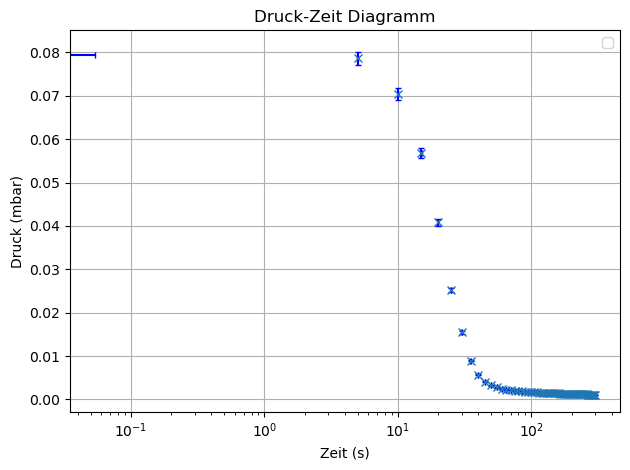

```
61
```

```python
t3_3 = np.array([0.0795, 0.0786, 0.0705, 0.0569, 0.0408, 0.0252, 0.0155, 0.00894, 0.00573, 0.00408, 0.00326, 0.00277, 0.00248, 0.00227, 0.00211, 0.00201, 0.00195, 0.00186, 0.00182, 0.00175, 0.00168, 0.00163, 0.00161, 0.00157, 0.00154, 0.00150, 0.00147, 0.00144, 0.00143, 0.00142, 0.00139, 0.00138, 0.00137, 0.00134, 0.00132, 0.00130, 0.00130, 0.00129, 0.00127, 0.00127, 0.00126, 0.00126, 0.00125, 0.00124, 0.00122, 0.00122, 0.00121, 0.00120, 0.00119, 0.00119, 0.00118, 0.00115, 0.00114, 0.00113, 0.00112, 0.00111, 0.00111, 0.00110, 0.00110, 0.00110, 0.00109])

t=np.arange(0, len(t3_3) * 5, 5)

#Unsicherheiten
delta_p = np.zeros_like(t3_3)
for i, p in enumerate(t3_3):
    if 5e-4 <= p < 1e-3:
        delta_p[i] = 0.10 * p
    elif 1e-3 <= p < 1e2:
        delta_p[i] = 0.02 * p
    elif 1e2 <= p <= 1e3:
        delta_p[i] = 0.25 * p
    else:
        delta_p[i] = 0.02 * p


plt.xscale('log')
plt.errorbar(t, t3_3, yerr=delta_p, xerr=0.0539, fmt='x', ecolor='blue', capsize=2)
plt.xlabel('Zeit (s)')
plt.ylabel('Druck (mbar)')
plt.title('Druck-Zeit Diagramm')
plt.grid(True)
plt.legend()
plt.tight_layout()
plt.show()
print(len(t3_3))
```

```python
def S_err(t, p, t_next, p_next, V, n=1, dp=0.196, dt_err=0.0539):
    dt = t_next - t
    if dt <= 0:
        return np.nan

    ln_term = np.log(p / p_next)
    rel_dp = dp / p                    # relativer Druckfehler


    term1 = (V / (n * dt)) * rel_dp                    # Druckbeitrag
    term2 = (V * np.abs(ln_term)) / (n * dt**2) * dt_err   # Zeitbeitrag


    s_value = (V / (n * dt)) * np.abs(ln_term)
    err = np.sqrt(term1**2 + term2**2)


    return np.minimum(err, s_value * 0.3)



plt.figure(figsize=(12, 7))

x_err = 0.005 * np.array(t_plot)

plt.errorbar(x=t_plot,
             y=S,
             xerr=x_err,
             yerr = 0.05 * np.ones_like(S),
             fmt='x',
             ls='none',
             capsize=2,
             color='blue',
             label='S(p)')

mean_S = mean(S, 5, 8)
plt.axhline(y=mean_S, xmin=0.397, xmax=0.71, color='orange', linewidth=2.5,
            label=f'Mittelwert Bereich I-II: {mean_S:.3f} l/s')


def mean(list,start, finish):
    sum = 0
    i = 0
    for _ in range(start,finish+1):
        sum += list[_]
        i += 1
    return sum/i

plt.axvline(x=t3_3[8], color='red', linestyle='--', alpha=0.7)
plt.axvline(x=t3_3[5], color='red', linestyle='--', alpha=0.7)

plt.title('Saugvermögen $S(p)$', fontsize=14)
plt.xlabel('Druck $p$ [mbar]', fontsize=12)
plt.ylabel(r'$S_p$ [$\frac{l}{s}$]', fontsize=12)

plt.xscale('log')
plt.ylim(-0.5, 2.0)
plt.xlim(0.0008, 0.1)

plt.grid(True, which='both', ls='--', alpha=0.6)
plt.legend(fontsize=11)

plt.text(0.04, 1.7, 'Bereich I',   fontweight='bold', fontsize=12)
plt.text(0.0089, 1.7, 'Bereich II', fontweight='bold', fontsize=12)
plt.text(0.00215, 1.7, 'Bereich III', fontweight='bold', fontsize=12)

plt.tight_layout()
plt.show()
```

[output not shown]

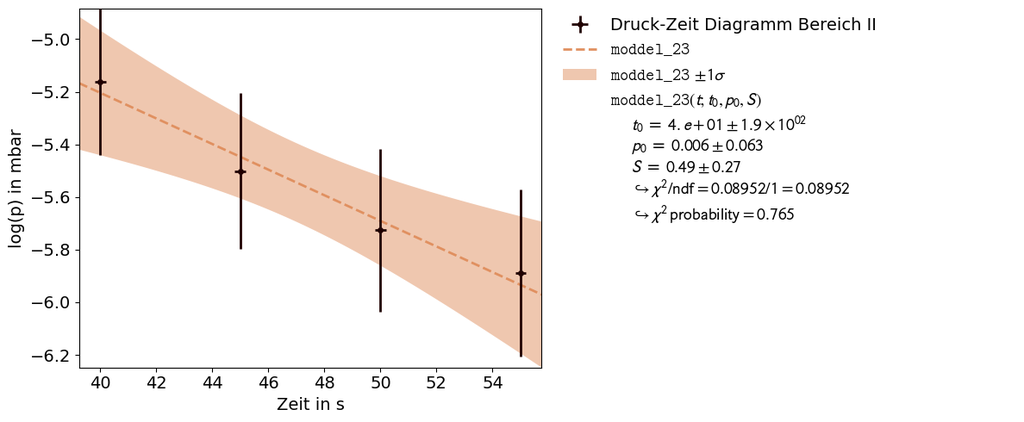

```python
def moddel_23(t,t_0=t[8],p_0=t3_3[8],S=mean(list=S,start=8,finish=12)):
    return np.log(p_0*np.exp(-(S)/(V)*(t-t_0)))

dataset_T3 = kafe2.XYContainer(x_data=t[8:12],y_data=np.log(t3_3[8:12]))
dataset_T3.axis_labels=['Zeit in s', 'log(p) in mbar']
dataset_T3.label='Druck-Zeit Diagramm Bereich II'
dataset_T3.add_error(axis='x',err_val=0.196)
dataset_T3.add_error(axis='y',err_val=0.0539,relative=True)
fit_T3 = kafe2.Fit(dataset_T3,model_function=moddel_23)
fit_T3.limit_parameter("t_0", lower=0)
fit_T3.do_fit()
fit_result_T3=kafe2.Plot([fit_T3])
params_3=fit_T3.parameter_values
params_err_3=fit_T3.parameter_errors
fit_result_T3.plot()
plt.show()
```

**D I S K U S S I O N**

## Aufgabe 3: Einfache Experimente im Vakuum

### Aufgabe 3.1: Statische Kalibration von T3

Führen Sie mit Hilfe des Referenzvolumes RV eine statische Kalibration des Vakuummeters T3 durch.

**V E R S U C H S B E S C H R E I B U N G**

Zur Kalibration des Vakuummeters T3 wird ein einstufiges statisches Kalibrationsverfahren mit dem Referenzvolumen $RV$ durchgeführt. Grundlage ist das Boyle-Mariotte-Gesetz.

Zunächst wird der Rezipient evakuiert und durch Schließen von V2 vom restlichen System getrennt. Anschließend wird durch wiederholtes Öffnen von V3 ein Druckausgleich zwischen Rezipient und Referenzvolumen hergestellt. Der dabei von T3 angezeigte Druck $p_{\mathrm{RZ}}^{\mathrm{(T3)}}$ wird nach Erreichen des Gleichgewichtszustands aufgenommen. Danach wird V3 wieder geschlossen und über B2 erneut Atmosphärendruck im Referenzvolumen eingestellt. Dieser Vorgang wird bis zu einem Druck von etwa $80\,\mathrm{mbar}$ wiederholt.

Die Druckänderung ergibt sich aus

$$ \Delta p_i = \frac{V_{\mathrm{RV}}}{V_{\mathrm{RV}}+V_{\mathrm{RZ}}} \left(p_0-p_{\mathrm{RZ},i}\right). $$

Mit

$$ p_{\mathrm{RZ},i+1} = p_{\mathrm{RZ},i}+\Delta p_i $$

werden die tatsächlichen Druckwerte rekursiv bestimmt. Aus den Datenpunkten

$$ \left( p_{\mathrm{RZ},i}, p_{\mathrm{RZ},i}^{\mathrm{(T3)}} \right) $$

wird anschließend die Kalibrationskurve

$$ K\left(p_{\mathrm{RZ}}, p_{\mathrm{RZ}}^{\mathrm{(T3)}}\right) $$

des Vakuummeters T3 erstellt.

Zunächst wird ein linearer Fit, dann ein Fit zu einem Polynom höherer Ordnung gemacht. Die Unsicherheiten der aufgenommenen Messwerte $p_{\mathrm{RZ},i}^{\mathrm{(T3)}}$ wurden dabei als 0.5 % angenommen. Dieser Fehler wurde entsprechend der Auflösung der Anzeige gewählt.

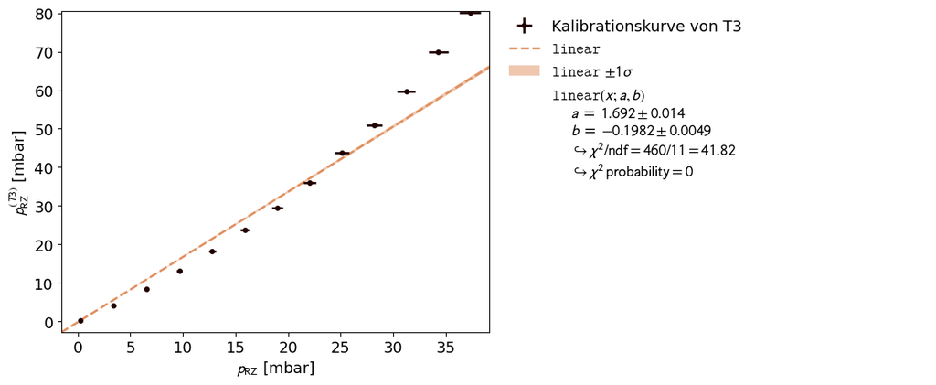

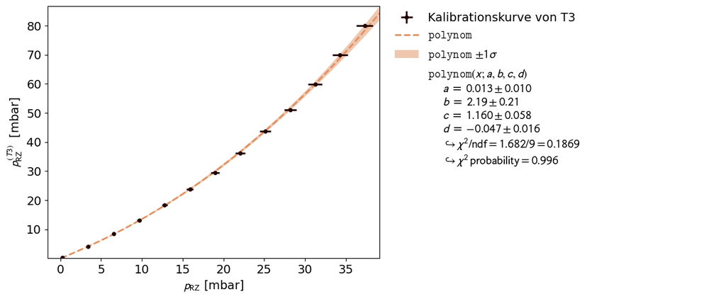

```python
import numpy as np
import matplotlib.pyplot as plt
from uncertainties import ufloat
import uncertainties.unumpy as unp
from kafe2 import Fit, MultiFit, Plot, HistFit, HistContainer, XYContainer


uV_RV = ufloat(0.034, 0)#in l
uV_RZ = ufloat(10.8, 0.3) #in l
up_0 = ufloat(1000,1) #in mbar

p_RZ_T3 = np.array([0.285, 4.05, 8.48, 13.1, 18.3, 23.8, 29.5, 36.1, 43.7, 51.0, 59.8, 70.0, 80.1,96.6, 115.0, 134, 153, 176, 217, 251])
up_RZ_T3 = unp.uarray(p_RZ_T3, p_RZ_T3*0.005)


ufaktor = uV_RV / (uV_RV + uV_RZ)

# Array für berechnete reale Drücke
up_RZ = unp.uarray(np.zeros(len(up_RZ_T3)), 0)

# Startwert
up_RZ[0] = up_RZ_T3[0]

# Rekursive Berechnung
for i in range(len(up_RZ) - 1):
    delta_p = ufaktor * (up_0 - up_RZ[i])
    up_RZ[i + 1] = up_RZ[i] + delta_p

# modelle
def polynom(x, a, b, c, d):
    return a*x**b + c*x+d

def linear(x, a, b):
    return a*x + b

# cutte bei 80 mbar

up_RZ_T3_cut = up_RZ_T3[0:13]
up_RZ_cut = up_RZ[0:13]

xydata = XYContainer( unp.nominal_values(up_RZ_cut), unp.nominal_values(up_RZ_T3_cut))
xydata.add_error(axis='x', err_val=unp.std_devs(up_RZ_cut))
xydata.add_error(axis= 'y', err_val= unp.std_devs(up_RZ_T3_cut))
xydata.label= "Kalibrationskurve von T3"

fit = Fit(data=xydata, model_function=linear)

# do the fit
fit.do_fit()
plot = Plot(fit)

# data
plot.x_label = r"$p_{\mathrm{RZ}}$ [mbar]"
plot.y_label = r"$p_{\mathrm{RZ}}^{(T3)}$ [mbar]"
plot.plot()
plt.show()

# create the Fit object by specifying a density function
fit = Fit(data=xydata, model_function=polynom)

# do the fit
fit.do_fit()
plot = Plot(fit)

# data
plot.x_label = r"$p_{\mathrm{RZ}}$ [mbar]"
plot.y_label = r"$p_{\mathrm{RZ}}^{(T3)}$  [mbar]"
plot.plot()
plt.show()
```

Die Tupel $\left(p_{\mathrm{RZ},i},p_{\mathrm{RZ},i}^{\mathrm{(T3)}}\right)$ wurden wie oben erklärt bestimmt und auf zwei Modelle gefittet. Das lineare Modell zeigt gerade bei höher werdenden Drücken eine geringe Übereinstimmung mit den Messdaten. Das kann man auch an dem sehr hohen $\Chi^2/\alpha$ - Wert von 41.82 sehen. Das zweite Modell hat zusätzlich zu dem linearen Anteil noch einen Term höherer Ordnung:

$$ f(x) = a \cdot x^b + c \cdot x + d. $$

Da die Datenpunkte deutlich von dem idealen Modell $p_{\mathrm{RZ}}^{\mathrm{(T3)}}(p_{\mathrm{RZ}}) = \alpha\,p_{\mathrm{RZ}}+\beta$ (mit $\beta$ = 0 und $\alpha$ = 1) abweichen, kann man gerade bei hohen Drücken von einer ungenügenden Kalibration des Wärmeleitungs-Vakuummeters ausgehen.

### Aufgabe 3.2: Elektrische Durchschlagfestigkeit

- Untersuchen Sie die elektrische Durchschlagfestigkeit der Kugelelektroden (KE) als Funktion des Umgebungsdrucks für Luft.
- Diese Aufgabe kann nur an den Apparaturen 151 und 152 durchgeführt werden.

**V E R S U C H S B E S C H R E I B U N G**

In diesem Versuch wird die elektrische Durchschlagfestigkeit der Kugelelektroden (KE) in Luft als Funktion des Umgebungsdrucks untersucht. Dazu wird die Spannung $U_{\mathrm{KE}}$ bestimmt, bei der zwischen den Elektroden eine Gasentladung beziehungsweise ein Plasma auftritt.

Zunächst wird der Rezipient ausschließlich mit der Drehschieberpumpe (DSP) evakuiert, während die Turbomolekularpumpe (TMP) ausgeschaltet bleibt. Die Messung beginnt bei Atmosphärendruck. Für jeden Messpunkt wird nach Erreichen des gewünschten Drucks das Ventil V1 geschlossen, damit der Druck im Rezipienten konstant bleibt. Anschließend wird die Spannung zwischen den Kugelelektroden schrittweise erhöht, bis eine Entladung beobachtet wird. Der zugehörige Druck sowie die Durchbruchsspannung werden notiert.

Der Druck wird danach schrittweise weiter abgesenkt, zunächst bis etwa

$$ p \approx 0.08\,\mathrm{mbar}. $$

Um zusätzliche Messpunkte bei kleineren Drücken zu erhalten, wird anschließend auch die TMP verwendet, bis der minimale erreichbare Druck von ungefähr

$$ p \lesssim 10^{-4}\,\mathrm{mbar} $$

erreicht ist. Danach wird die TMP abgeschaltet und V2 geschlossen. Durch den nun langsam ansteigenden Druck können weitere Messwerte aufgenommen werden.

Insgesamt wurden 19 Datenpunkte der Form

$$ \left(U_{\mathrm{KE}},\,p_{\mathrm{RZ}}\right) $$

bestimmt werden. Spannungen werden mit einem Multimeter gemessen.

Wie im vorherigen Versuch werden Drücke p mit einer Unsicherheit von 0.5 % versehen. Da die Spannungen während der Messung stark fluktuiert haben, wird hier von einer Unsicherheit von 5 % ausgegangen.

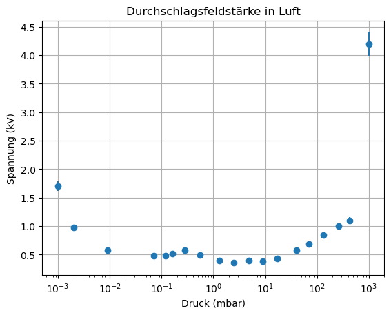

```python
import numpy as np
U1 = np.array([4.2, 1.1, 1.0, 0.84, 0.68, 0.57, 0.43, 0.38, 0.39, 0.36, 0.395, 0.49, 0.58, 0.51, 0.48])#in kV
p1 = np.array([1000, 430, 258, 135, 70, 40, 17, 9, 4.9, 2.5, 1.3, 0.56, 0.28, 0.16, 0.12])#in mbar

U2 = np.array([1.7, 0.97, 0.58, 0.48])#in kV
p2 = np.array([0.001, 0.002, 0.009, 0.07])# in mbar

U = np.concatenate((U1, U2))
p = np.concatenate((p1, p2))

plt.figure()
plt.errorbar(p, U, xerr=0.005*p, yerr=0.05*U, fmt='o')
plt.xlabel('Druck (mbar)')
plt.ylabel('Spannung (kV)')

plt.xscale("log")
plt.title('Durchschlagsfeldstärke in Luft')
plt.grid()
plt.show()
```

Die aufgenommenen Spannungen entsprechen jeweils dem Maximalwert unmittelbar vor der Entladung. Sobald zwischen den Kugeln ein Ladungsausgleich durch Funkenüberschlag oder bei niedrigen Drücken durch eine Glimmentladung stattfindet, sinkt die Spannung leicht ab, da nun ein Strom fließt.

Zur besseren Darstellung des Bereichs minimaler Überschlagsspannung wurde eine logarithmische x-Achse gewählt. Es ist erkennbar, dass die Überschlagsspannung bei sehr kleinen Drücken wieder ansteigt. Anfangs lag sie sogar oberhalb der maximal verfügbaren Spannung von $9\,\mathrm{kV}$ und konnte daher nicht gemessen werden.

Liegt die mittlere freie Weglänge der Gasteilchen in der Größenordnung des Elektrodenabstands, so wird die Überschlagsspannung besonders klein. Wird der Druck weiter erhöht, verkleinert sich die mittlere freie Weglänge erneut, wodurch die Durchschlagfestigkeit wieder zunimmt.

### Aufgabe 3.3: Aufdampfen von Indium

Dampfen Sie mit Hilfe einer Schablone bei zwei verschiedenen Drucken Indium auf eine Plexiglasplatte auf.

Im letzten Versuch wurde eine Indium-Schicht durch eine Kreisblende auf eine Plexiglasscheibe aufgedampft. Dazu wurde ein Verdampferschiffchen mithilfe eines Heizstroms erhitzt, sodass das darauf platzierte Indium verdampfte und sich auf der Scheibe ablagerte.

Die Beschichtung sollte bei zwei verschiedenen Drücken durchgeführt werden:

$$ p_1 \lesssim10^{-4}\,\mathrm{mbar}, \qquad p_2 \approx 10^{-3}\,\mathrm{mbar}. $$

Im Druckbereich von $p_1$ war ein Heizstrom von etwa $30\,\mathrm{A}$ erforderlich. Der aufgedampfte Indiumkreis (s. Bild unterer Kreis) war nicht viel größer als die Kreisblende und besaß scharfe Ränder. Dies lässt sich dadurch erklären, dass bei sehr niedrigem Druck nur wenige Gasatome vorhanden sind, welche den Indiumdampf streuen könnten. Der Dampf erreicht die Plexiglasscheibe daher nahezu geradlinig.

Im Druckbereich von $p_2$ war der Indiumkreis (s. Bild oberer Kreis) größer und an den Rändern unschärfer. Das liegt daran, dass mehr Gasatome vorhanden sind, welche den Indiumdampf streuen und ablenken.

Außerdem wurde beobachtet, dass im Bereich $p_2$ ein größerer Heizstrom benötigt wurde ($\approx$ 40 A). Mit zunehmendem Druck verbessert sich die Wärmeleitung des Gases, wodurch mehr Wärme abgeführt wird. Um dennoch die notwendige Verdampfungstemperatur zu erreichen, ist daher ein größerer Heizstrom erforderlich.

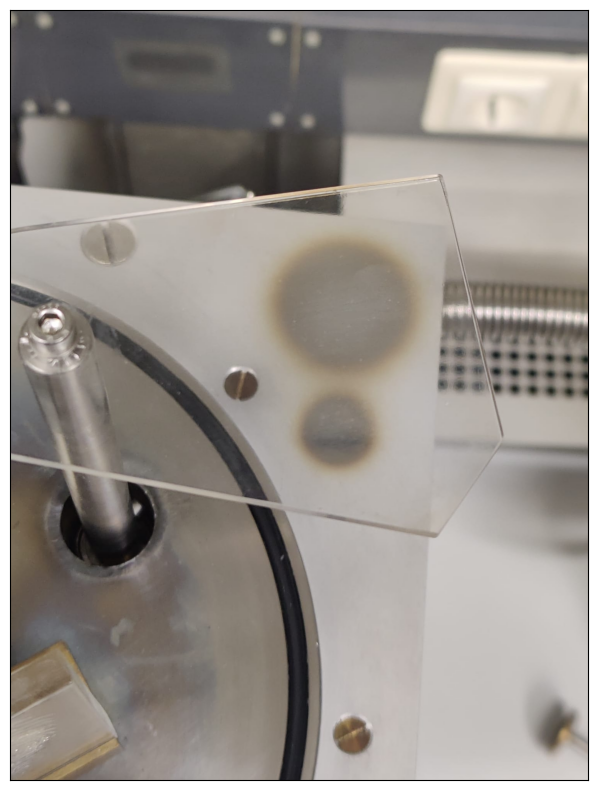

```python
from os import getcwd
PWD=getcwd()

import matplotlib.pyplot as plt
import matplotlib.image as mpimg

img = plt.figure("demo", figsize=(10.0, 10.0))
img = mpimg.imread("3_3.jpeg".format(PWD=PWD))
imgplot = plt.imshow(img)
imgplot.axes.get_xaxis().set_visible(False)
imgplot.axes.get_yaxis().set_visible(False)
plt.show()
```

# Beurteilung

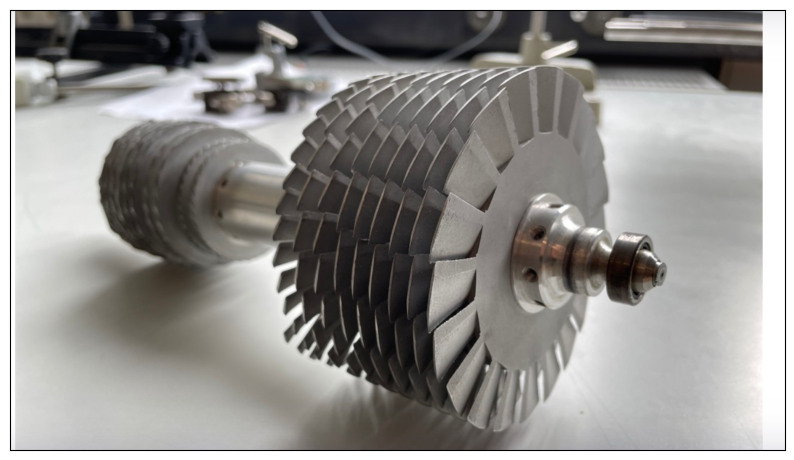

```python
from os import getcwd
PWD=getcwd()

import matplotlib.pyplot as plt
import matplotlib.image as mpimg

img = plt.figure("demo", figsize=(10.0, 10.0))
img = mpimg.imread("Beurteilung.png".format(PWD=PWD))
imgplot = plt.imshow(img)
imgplot.axes.get_xaxis().set_visible(False)
imgplot.axes.get_yaxis().set_visible(False)
plt.show()
```